# Final Project

Qiaojuan Tu

12/13/2020

## Purpose

As we all know that U.S has been one of the top countries that imports a huge amount of goods from China. We can see that goods from China has played an important role in American people’s life. So my interested research question is:

1. How the trend of the imports from China looks like, increasing or decreasing?
2. What are some of the major imports from China?
3. How the trend from China compared to other major imports countries that U.S. imports from, such as Canada and Mexico?

## Data Access

```r
library(readr)
library(ggplot2)
library(tidyr)
library(DataComputing)
library(tidyverse)
#import saved data
Data <- read_csv("WITS-Partner.csv") #the primary data set
head(Data)
```

```
## # A tibble: 6 x 33
##   `Reporter Name` `Partner Name` `Trade Flow` `Product Group` Indicator `1991`
##   <chr>           <chr>          <chr>        <chr>           <chr>      <dbl>
## 1 United States   Afghanistan    Import       All Products    Import (~ 4.60e3
## 2 United States   Albania        Import       All Products    Import (~ 3.57e3
## 3 United States   Algeria        Import       All Products    Import (~ 2.28e6
## 4 United States   Andorra        Import       All Products    Import (~ 2.10e2
## 5 United States   Angola         Import       All Products    Import (~ 1.91e6
## 6 United States   Anguila        Import       All Products    Import (~ 1.42e3
## # ... with 27 more variables: `1992` <dbl>, `1993` <dbl>, `1994` <dbl>,
## #   `1995` <dbl>, `1996` <dbl>, `1997` <dbl>, `1998` <dbl>, `1999` <dbl>,
## #   `2000` <dbl>, `2001` <dbl>, `2002` <dbl>, `2003` <dbl>, `2004` <dbl>,
## #   `2005` <dbl>, `2006` <dbl>, `2007` <dbl>, `2008` <dbl>, `2009` <dbl>,
## #   `2010` <dbl>, `2011` <dbl>, `2012` <dbl>, `2013` <dbl>, `2014` <dbl>,
## #   `2015` <dbl>, `2016` <dbl>, `2017` <dbl>, `2018` <dbl>
```

```r
ChinaProduct <- read_csv("WITS-ChinaProduct.csv")
head(ChinaProduct)
```

```
## # A tibble: 6 x 31
##   `Reporter Name` `Partner Name`  Year `Trade Flow` `Product Group`
##   <chr>           <chr>          <dbl> <chr>        <chr>
## 1 United States   China           2018 Import       All Products
## 2 United States   China           2018 Import       Capital goods
## 3 United States   China           2018 Import       Consumer goods
## 4 United States   China           2018 Import       Intermediate g~
## 5 United States   China           2018 Import       Raw materials
## 6 United States   China           2018 Import       Animal
## # ... with 26 more variables: `Import (US$ Thousand)` <dbl>, `Import Product
## #   Share (%)` <dbl>, `AHS Simple Average (%)` <dbl>, `AHS Weighted Average
## #   (%)` <dbl>, `AHS Total Tariff Lines` <dbl>, `AHS Dutiable Tariff Lines
## #   Share (%)` <dbl>, `AHS Duty Free Tariff Lines Share (%)` <dbl>, `AHS
## #   Specific Tariff Lines Share (%)` <dbl>, `AHS AVE Tariff Lines Share
## #   (%)` <dbl>, `AHS MaxRate (%)` <dbl>, `AHS MinRate (%)` <dbl>, `AHS
## #   SpecificDuty Imports (US$ Thousand)` <dbl>, `AHS Dutiable Imports (US$
## #   Thousand)` <dbl>, `AHS Duty Free Imports (US$ Thousand)` <dbl>, `MFN Simple
## #   Average (%)` <dbl>, `MFN Weighted Average (%)` <dbl>, `MFN Total Tariff
## #   Lines` <dbl>, `MFN Dutiable Tariff Lines Share (%)` <dbl>, `MFN Duty Free
## #   Tariff Lines Share (%)` <dbl>, `MFN Specific Tariff Lines Share (%)` <dbl>,
## #   `MFN AVE Tariff Lines Share (%)` <dbl>, `MFN MaxRate (%)` <dbl>, `MFN
## #   MinRate (%)` <dbl>, `MFN SpecificDuty Imports (US$ Thousand)` <dbl>, `MFN
## #   Dutiable Imports (US$ Thousand)` <dbl>, `MFN Duty Free Imports (US$
## #   Thousand)` <dbl>
```

```r
#inspect the the datasets
str(Data)
```

```
## tibble [238 x 33] (S3: spec_tbl_df/tbl_df/tbl/data.frame)
##  $ Reporter Name: chr [1:238] "United States" "United States" "United States" "United States" ...
##  $ Partner Name : chr [1:238] "Afghanistan" "Albania" "Algeria" "Andorra" ...
##  $ Trade Flow   : chr [1:238] "Import" "Import" "Import" "Import" ...
##  $ Product Group: chr [1:238] "All Products" "All Products" "All Products" "All Products" ...
##  $ Indicator    : chr [1:238] "Import (US$ Thousand)" "Import (US$ Thousand)" "Import (US$ Thousand)" "Import (US$ Thousand)" ...
##  $ 1991         : num [1:238] 4598 3571 2277976 210 1914486 ...
##  $ 1992         : num [1:238] 2.37e+03 5.54e+03 1.69e+06 6.49e+01 2.44e+06 ...
##  $ 1993         : num [1:238] 3003 8138 1710782 146 2237486 ...
##  $ 1994         : num [1:238] 6333 6622 1664330 123 2209202 ...
##  $ 1995         : num [1:238] 5712 10178 1807210 253 2390159 ...
##  $ 1996         : num [1:238] 17796 11178 2270363 2638 2855055 ...
##  $ 1997         : num [1:238] 11149 12468 2645618 299 2935766 ...
##  $ 1998         : num [1:238] 17520 13081 1798656 141 2450877 ...
##  $ 1999         : num [1:238] 10102 9471 1951535 135 2574614 ...
##  $ 2000         : num [1:238] 781 7767 2724270 344 3555286 ...
##  $ 2001         : num [1:238] 769 7270 2701903 221 3095899 ...
##  $ 2002         : num [1:238] 4157 6222 2555072 810 3283495 ...
##  $ 2003         : num [1:238] 62705 4697 5121535 290 4508910 ...
##  $ 2004         : num [1:238] 25106 12212 7926532 970 4796800 ...
##  $ 2005         : num [1:238] 67650 38853 10931931 712 8846627 ...
##  $ 2006         : num [1:238] 45827 25067 16088930 2745 12174574 ...
##  $ 2007         : num [1:238] 76810 10122 18431958 459 12925965 ...
##  $ 2008         : num [1:238] 86907 12435 20032289 903 19497728 ...
##  $ 2009         : num [1:238] 124108 15804 11150476 542 9703061 ...
##  $ 2010         : num [1:238] 87474 31776 14943690 482 12273945 ...
##  $ 2011         : num [1:238] 26637 27851 14912503 619 13833012 ...
##  $ 2012         : num [1:238] 36760 18857 9993335 429 9823874 ...
##  $ 2013         : num [1:238] 45514 22777 4830872 1405 8742942 ...
##  $ 2014         : num [1:238] 72810 70266 4794597 1251 5837752 ...
##  $ 2015         : num [1:238] 24494 163095 3537248 4888 2917054 ...
##  $ 2016         : num [1:238] 34476 125857 3418707 6690 2976766 ...
##  $ 2017         : num [1:238] 14694 43365 3991780 13762 2686494 ...
##  $ 2018         : num [1:238] 29792 70407 4781629 16087 2768925 ...
##  - attr(*, "spec")=
##   .. cols(
##   ..   `Reporter Name` = col_character(),
##   ..   `Partner Name` = col_character(),
##   ..   `Trade Flow` = col_character(),
##   ..   `Product Group` = col_character(),
```

[output cut: 15 more lines]

```
##   ..   `2005` = col_double(),
##   ..   `2006` = col_double(),
##   ..   `2007` = col_double(),
##   ..   `2008` = col_double(),
##   ..   `2009` = col_double(),
##   ..   `2010` = col_double(),
##   ..   `2011` = col_double(),
##   ..   `2012` = col_double(),
##   ..   `2013` = col_double(),
##   ..   `2014` = col_double(),
##   ..   `2015` = col_double(),
##   ..   `2016` = col_double(),
##   ..   `2017` = col_double(),
##   ..   `2018` = col_double()
##   .. )
```

```r
str(ChinaProduct)
```

```
## tibble [21 x 31] (S3: spec_tbl_df/tbl_df/tbl/data.frame)
##  $ Reporter Name                          : chr [1:21] "United States" "United States" "United States" "United States" ...
##  $ Partner Name                           : chr [1:21] "China" "China" "China" "China" ...
##  $ Year                                   : num [1:21] 2018 2018 2018 2018 2018 ...
##  $ Trade Flow                             : chr [1:21] "Import" "Import" "Import" "Import" ...
##  $ Product Group                          : chr [1:21] "All Products" "Capital goods" "Consumer goods" "Intermediate goods" ...
##  $ Import (US$ Thousand)                  : num [1:21] 5.63e+08 2.67e+08 2.43e+08 4.09e+07 4.96e+06 ...
##  $ Import Product Share (%)               : num [1:21] 100 47.33 43.2 7.27 0.88 ...
##  $ AHS Simple Average (%)                 : num [1:21] 4.23 1.32 7.1 4.03 1.53 ...
##  $ AHS Weighted Average (%)               : num [1:21] 2.77 0.48 5.4 2.66 1.34 ...
##  $ AHS Total Tariff Lines                 : num [1:21] 9449 1519 3379 3573 532 ...
##  $ AHS Dutiable Tariff Lines Share (%)    : num [1:21] 54.2 41.3 60.9 59.1 21.6 ...
##  $ AHS Duty Free Tariff Lines Share (%)   : num [1:21] 37.4 57.7 26.7 36.2 51.3 ...
##  $ AHS Specific Tariff Lines Share (%)    : num [1:21] 1.64 0.26 3.37 0.7 0 2.26 0 4.13 1.52 0 ...
##  $ AHS AVE Tariff Lines Share (%)         : num [1:21] 6.74 0.66 9.03 3.97 27.07 ...
##  $ AHS MaxRate (%)                        : num [1:21] 3000 25 3000 133 350 ...
##  $ AHS MinRate (%)                        : num [1:21] 0 0 0 0 0 0 0 0 0 0 ...
##  $ AHS SpecificDuty Imports (US$ Thousand): num [1:21] 1790572 35946 1513564 193357 0 ...
##  $ AHS Dutiable Imports (US$ Thousand)    : num [1:21] 2.67e+08 7.41e+07 1.63e+08 2.21e+07 1.95e+06 ...
##  $ AHS Duty Free Imports (US$ Thousand)   : num [1:21] 2.76e+08 1.83e+08 6.95e+07 1.49e+07 1.00e+06 ...
##  $ MFN Simple Average (%)                 : num [1:21] 4.23 1.32 7.1 4.03 1.53 ...
##  $ MFN Weighted Average (%)               : num [1:21] 2.77 0.48 5.4 2.66 1.34 ...
##  $ MFN Total Tariff Lines                 : num [1:21] 9449 1519 3379 3573 532 ...
##  $ MFN Dutiable Tariff Lines Share (%)    : num [1:21] 54.2 41.3 60.9 59.1 21.6 ...
##  $ MFN Duty Free Tariff Lines Share (%)   : num [1:21] 37.4 57.7 26.7 36.2 51.3 ...
##  $ MFN Specific Tariff Lines Share (%)    : num [1:21] 1.64 0.26 3.37 0.7 0 2.26 0 4.13 1.52 0 ...
##  $ MFN AVE Tariff Lines Share (%)         : num [1:21] 6.74 0.66 9.03 3.97 27.07 ...
##  $ MFN MaxRate (%)                        : num [1:21] 3000 25 3000 133 350 ...
##  $ MFN MinRate (%)                        : num [1:21] 0 0 0 0 0 0 0 0 0 0 ...
##  $ MFN SpecificDuty Imports (US$ Thousand): num [1:21] 1790572 35946 1513564 193357 0 ...
##  $ MFN Dutiable Imports (US$ Thousand)    : num [1:21] 2.67e+08 7.41e+07 1.63e+08 2.21e+07 1.95e+06 ...
##  $ MFN Duty Free Imports (US$ Thousand)   : num [1:21] 2.76e+08 1.83e+08 6.95e+07 1.49e+07 1.00e+06 ...
##  - attr(*, "spec")=
##   .. cols(
##   ..   `Reporter Name` = col_character(),
##   ..   `Partner Name` = col_character(),
##   ..   Year = col_double(),
##   ..   `Trade Flow` = col_character(),
##   ..   `Product Group` = col_character(),
##   ..   `Import (US$ Thousand)` = col_double(),
```

[output cut: 11 more lines]

```
##   ..   `AHS Dutiable Imports (US$ Thousand)` = col_double(),
##   ..   `AHS Duty Free Imports (US$ Thousand)` = col_double(),
##   ..   `MFN Simple Average (%)` = col_double(),
##   ..   `MFN Weighted Average (%)` = col_double(),
##   ..   `MFN Total Tariff Lines` = col_double(),
##   ..   `MFN Dutiable Tariff Lines Share (%)` = col_double(),
##   ..   `MFN Duty Free Tariff Lines Share (%)` = col_double(),
##   ..   `MFN Specific Tariff Lines Share (%)` = col_double(),
##   ..   `MFN AVE Tariff Lines Share (%)` = col_double(),
##   ..   `MFN MaxRate (%)` = col_double(),
##   ..   `MFN MinRate (%)` = col_double(),
##   ..   `MFN SpecificDuty Imports (US$ Thousand)` = col_double(),
##   ..   `MFN Dutiable Imports (US$ Thousand)` = col_double(),
##   ..   `MFN Duty Free Imports (US$ Thousand)` = col_double()
##   .. )
```

```r
names(Data)
```

```
##  [1] "Reporter Name" "Partner Name"  "Trade Flow"    "Product Group"
##  [5] "Indicator"     "1991"          "1992"          "1993"
##  [9] "1994"          "1995"          "1996"          "1997"
## [13] "1998"          "1999"          "2000"          "2001"
## [17] "2002"          "2003"          "2004"          "2005"
## [21] "2006"          "2007"          "2008"          "2009"
## [25] "2010"          "2011"          "2012"          "2013"
## [29] "2014"          "2015"          "2016"          "2017"
## [33] "2018"
```

```r
names(ChinaProduct)
```

```
##  [1] "Reporter Name"
##  [2] "Partner Name"
##  [3] "Year"
##  [4] "Trade Flow"
##  [5] "Product Group"
##  [6] "Import (US$ Thousand)"
##  [7] "Import Product Share (%)"
##  [8] "AHS Simple Average (%)"
##  [9] "AHS Weighted Average (%)"
## [10] "AHS Total Tariff Lines"
## [11] "AHS Dutiable Tariff Lines Share (%)"
## [12] "AHS Duty Free Tariff Lines Share (%)"
## [13] "AHS Specific Tariff Lines Share (%)"
## [14] "AHS AVE Tariff Lines Share (%)"
## [15] "AHS MaxRate (%)"
```

[output cut: 16 more lines]

## Data Wrangling

```r
#Data wrangling for the primary data set: sort out China from the variable
Data1 <-
  Data %>%
  filter(`Partner Name` == "China") %>%
  gather(key = Year, value = import,"1991", "1992", "1993", "1994", "1995","1996", "1997", "1998", "1999","2000", "2001","2002", "2003", "2004", "2005", "2006", "2007", "2008", "2009", "2010", "2011", "2012", "2013", "2014", "2015", "2016", "2017", "2018") %>%
  mutate(import = `import`/1000000)%>%
  select(`import`, Year) %>%
  add_column(Country = "China", .after = 2)


#Data Wrangling for the secondary data set: Scaling the numbers and change the name of the variable
Data2 <-
  ChinaProduct %>%
  mutate(Import = `Import (US$ Thousand)`/1000000, Group=`Product Group` )



Data3 <-
  Data %>%
  filter(`Partner Name` == "Canada") %>%
  gather(key = Year, value = import, "1991", "1992", "1993", "1994", "1995","1996", "1997", "1998", "1999","2000", "2001","2002", "2003", "2004", "2005", "2006", "2007", "2008", "2009", "2010", "2011", "2012", "2013", "2014", "2015", "2016", "2017", "2018") %>%
  mutate(import = `import`/1000000) %>%
  select(`import`, Year)%>%
  add_column(Country="Canada", .after = 2)

Data4 <-
 Data %>%
  filter(`Partner Name` == "Mexico") %>%
  gather(key = Year, value = import, "1991", "1992", "1993", "1994", "1995","1996", "1997", "1998", "1999","2000", "2001","2002", "2003", "2004", "2005", "2006", "2007", "2008", "2009", "2010", "2011", "2012", "2013", "2014", "2015", "2016", "2017", "2018") %>%
  mutate(import = `import`/1000000) %>%
  select(`import`, Year)%>%
  add_column(Country="Mexico", .after = 2)


China_Canada <-
  full_join(Data1, Data3)
China_Mexico <-
  full_join(Data1, Data4)
```

## Data Visualization

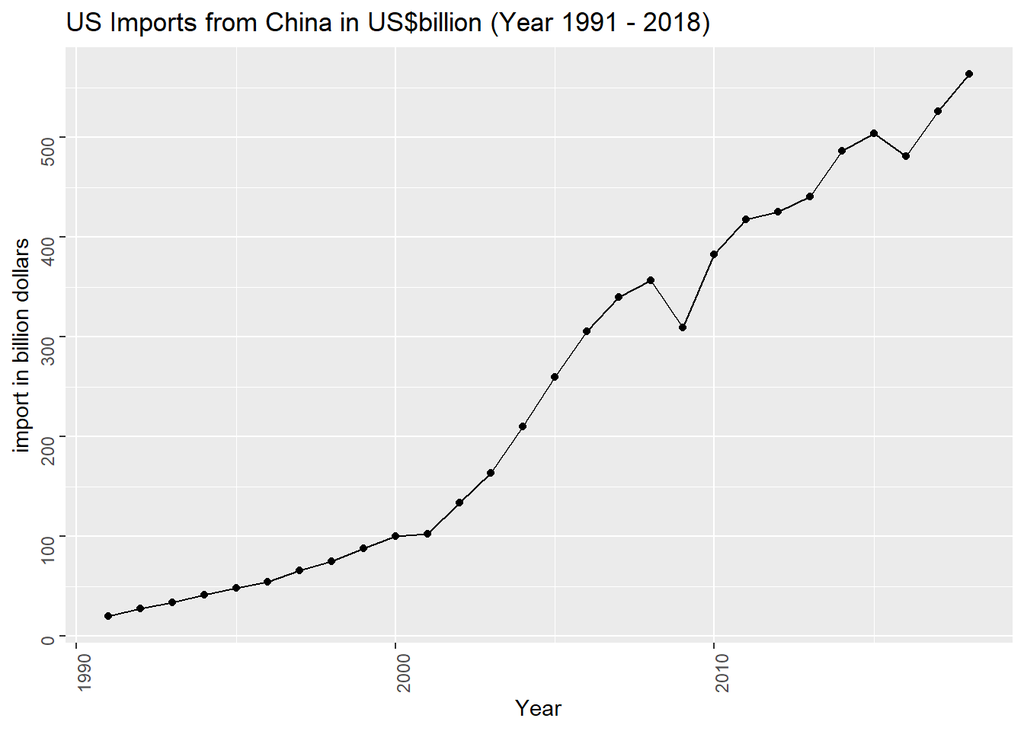

```r
#Trend for imports from China

Data1 %>%
   ggplot(aes(x=as.numeric(as.character(`Year`)), y = `import`)) + geom_point() +geom_line() + ggtitle("US Imports from China in US$billion (Year 1991 - 2018)") + theme(axis.text = element_text(angle = 90)) + labs(x="Year", y= "import in billion dollars")
```

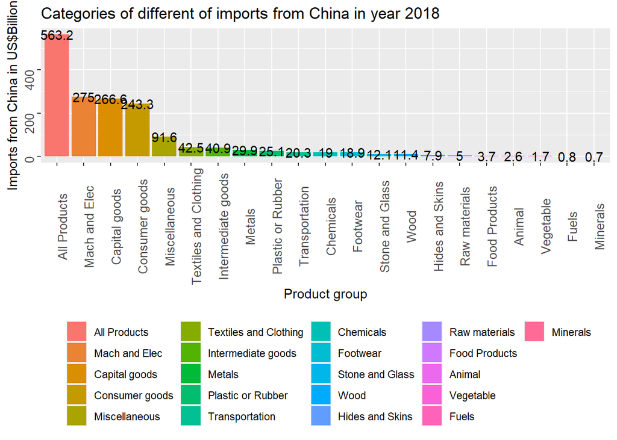

```r
#Bar graph to show the categories of imports
Data2 %>%
  mutate(Import = `Import (US$ Thousand)`/1000000, Group=`Product Group` ) %>%
  ggplot(aes(x = reorder(Group, -Import), y = round(Import, digits=3), fill = reorder(Group, -Import), label = round(Import, digits=2))) + geom_bar(stat = "identity")+theme(axis.text = element_text(size=10, angle = 90), legend.position = "bottom", legend.title = element_blank()) +ggtitle("Categories of different of imports from China in year 2018 ") + labs(x="Product group", y="Imports from China in US$Billion") + geom_text(aes(label= round(Import, digits=1), angle=0))
```

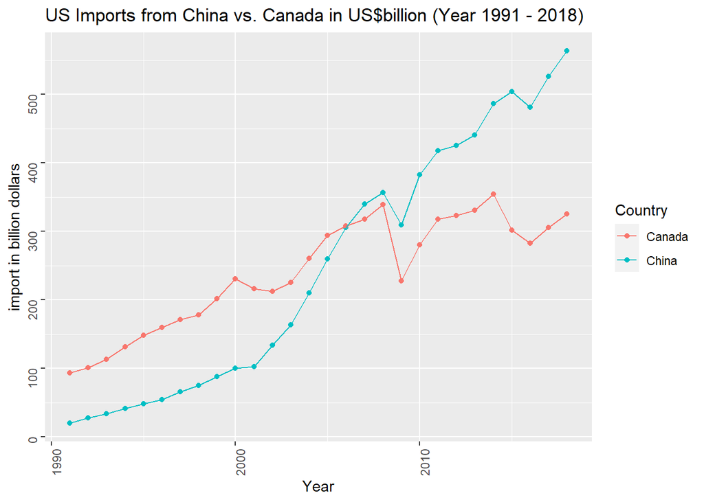

```r
#Layered dot graph for China and Canada
China_Canada %>%
  ggplot(aes(x=as.numeric(as.character(`Year`)), y = `import`, color = Country))+geom_point() +geom_line()+ ggtitle("US Imports from China vs. Canada in US$billion (Year 1991 - 2018)") + theme(axis.text = element_text(angle = 90)) + labs(x="Year", y= "import in billion dollars")
```

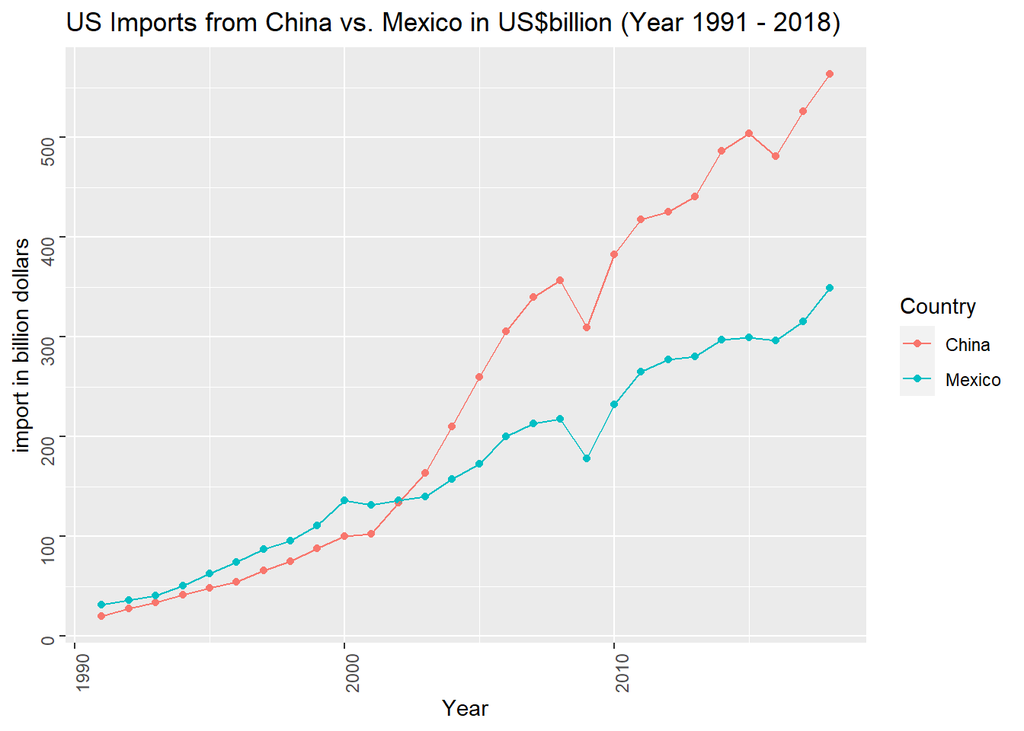

```r
#Layered dot graph for China and Mexico
China_Mexico %>%
  ggplot(aes(x=as.numeric(as.character(`Year`)), y = `import`, color = Country))+geom_point() +geom_line()+ ggtitle("US Imports from China vs. Mexico in US$billion (Year 1991 - 2018)") + theme(axis.text = element_text(angle = 90)) + labs(x="Year", y= "import in billion dollars")
```

## Key Takeaway and Anaswer the Research Question

1. Based on the visuals created above, we can conclude that from year 1991 tp 2018, the general trend of the U.S. imports from China is in an increasing rate, except for the year 2009 and 2016.
2. The top 3 categories of U.S. imports from China are Mechanical Goods and Electrical Goods, followed by Capital Goods and Consumer Goods.
3. The U.S. imports from Canada and Mexico are in a increasing trend as well, but China has been leading in the past decade or so. Also, we can see that all three countries experienced falls around year 2009 and 2016 where the Financial Crisis and the U.S. election occurred during those time.

## Challenges

During this project, I have encountered several challenges. First one is to figure out how to make different attributes fit in the graph where all the axis names and numbers can be seen properly. Another one is to make the Variable Year from a categorical variable to a numerical variable to the ggplot2 function can be functioned properly.

One of the technical challenge that I did not overcome is that I could not figure out a way to make the Canada and Mexico graphs put side by side in a facet likely situation, but I have failed to do that. I have tried seveal ways to make that happen, but non of them worked.